# Is the Bottle Filler in the Ricks Building actually faster than the fountain?

Daniel Bagley

2022-07-09

```r
#load relevant packages
pacman::p_load(car, tidyverse, googlesheets4, gt, ggsci, pander)
#read data off of google sheets
fountain <- read_sheet("1ezL77sIa6NroUrNnjeqidHkwFf9ZjmRck9NPqFw-ZPI")
#factorize fountain type
fountain$Type <- as.factor(fountain$Type)
#set R syntax legal names for the dataset columns
names(fountain) <- c("Type", "Time", "Date")
# create relevant test models
fountain_test <- t.test(Time ~ Type, data = fountain)
fountain_nova <- aov(Time ~ Type + Date, data = fountain)
```

## Background

The Mathematics Department at Brigham Young University-Idaho is housed in the second floor of the Thomas E. Ricks Building (referred to as the ‘Ricks building’ hereafter) of the university’s campus in Rexburg, Idaho. Next to the department offices is a pair of drinking fountains. These are the fountains most accessible to students in mathematics courses, which are on the other side of the hall from the department offices. Of the pair, one fountain was converted to a bottle filler during the onset of the COVID-19 pandemic. The other fountain was disabled for a time, and has since been re-activated following loosening of quarantine/masking protocols.

### Hypotheses

We will formally state our hypotheses as follows, where $\mu_{\text{Fountain}}$ represents the mean time to fill the bottle using the regular water fountain and $\mu_{\text{Filler}}$ represents the mean time to fill the bottle using the bottle filler fountain.
$$H_0: \mu_{\text{Fountain}} = \mu_{\text{Filler}} \\
H_a: \mu_{\text{Fountain}} \neq \mu_{\text{Filler}} \\$$

We will set a Level of Significance $\alpha = 0.05$ for this analysis.

## Methods

#### Data collection

The data were collected using a stopwatch and a 24 oz. (approx. 750 ml) water bottle, which was measured to determine its capacity. I held the bottle with one hand and used the stopwatch with the other so that each response could be measured by one individual. First, the lid was removed from the bottle, and the bottle was held near the spout of the water fountain. Then, the stopwatch was started at the same time I began applying constant pressure to the lever or switch of the fountain by leaning against it with my thigh. Since I am quite tall, those attempting to recreate this experiment might use their hip instead.

When recording measurements for the bottle filler, I simply held it under the stream of water until it reached the top of the bottle (where the threading of the lid begins), stopping the stopwatch immediately when it did so. For measurements using the regular fountain, it was necessary to hold the bottle at an angle that matched that of the fountain’s stream. Therefore, when the water reached the top of the bottle and began overfilling, the bottle was not actually full due to its angle. In order to prevent any bias towards the fountain due to this fact, when the water reached the top of the bottle and began to overflow, I quickly righted the bottle and switched from the regular fountain to the filler, which I used to complete the filling of the bottle.

#### Justifying the tilt-and-switch

While most people probably wouldn’t mind having their bottle being a few drops less full (about 1.5 ounces) due to the necessity of angling the bottle to use the regular fountain, I felt this adjustment using the filler was necessary to avoid concluding that the regular fountain’s fill time was lower than in actual fact. That being said, the time (though very little) to switch between fountains adds to the fill time, so I believe that we have given the bottle filler attachment fountain every possible chance to display greater efficiency than the regular fountain.

Lastly, it is crucial to note that I recorded measurements only when no one else was using (or waiting for) the fountains; I was not sure if both fountains operating at once would make them run slower due to drawing from the same water supply.

#### Date as a covariate

To avoid potential confounding due to taking measurements at different dates, I recorded the fill-time for each measurement and its date. I also randomized which fountain I used based on the date. Doing so will allow me to examine whether the date of data collection acts as a confounding variable for the fill time; we will use an ANCOVA to examine this in more detail later.

## Analysis

### Numerical summaries

```r
mosaic::favstats(Time ~ Type, data = fountain)[-10]
```

```
##       Type   min      Q1 median      Q3   max     mean        sd n
## 1   Filler 48.37 49.3425 49.615 50.0525 50.56 49.60167 0.7577709 6
## 2 Fountain 29.52 29.9150 30.435 31.5025 32.62 30.76833 1.2031196 6
```

### Testing Requirements

Because the sample size is small (6 each), we will utilize a QQ plot to assess the normality of the distribution of our data. As seen below, QQ plots of our two groups both fall well within the confidence interval of normality and follow a straight enough line that we feel confident in proceeding with testing.

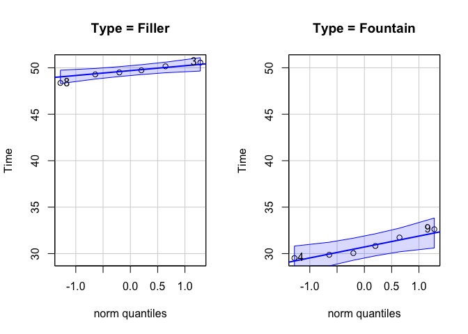

```r
qqPlot(Time ~ Type, data = fountain)
```

## Statistical testing

### Possible confouding by date

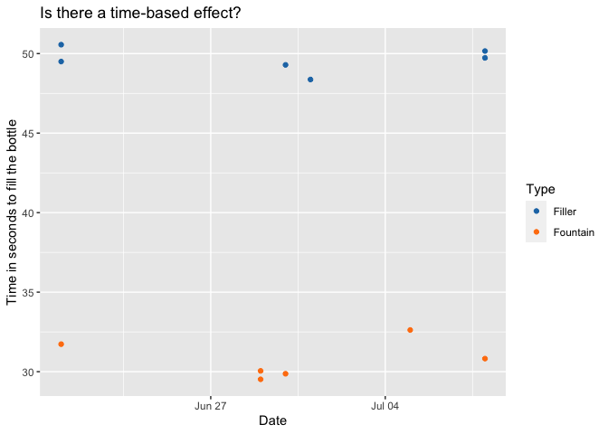

```r
ggplot(fountain, aes(y = Time, x = Date, color = Type)) +
  geom_point() +
  scale_color_d3() +
  labs(title = "Is there a time-based effect?",
       x = "Date",
       y = "Time in seconds to fill the bottle")
```

We can support this visual evidence with a quick ANCOVA model, using Date as a covariate. In this case, if the date has no effect upon the fill time, we should see a non-significant p-value.

```r
pander(summary(fountain_nova))
```

Analysis of Variance Model

|  | Df | Sum Sq | Mean Sq | F value | Pr(>F) |
| --- | --- | --- | --- | --- | --- |
| **Type** | 1 | 1064 | 1064 | 947.4 | 1.975e-10 |
| **Date** | 1 | 0.0004679 | 0.0004679 | 0.0004166 | 0.9842 |
| **Residuals** | 9 | 10.11 | 1.123 | NA | NA |

### Test results

```r
pander(fountain_test, caption = "Student's t-test of fountain data")
```

| Test statistic | df | P value | Alternative hypothesis |
| --- | --- | --- | --- |
| 32.44 | 8.428 | 3.789e-10 * * * | two.sided |

| mean in group Filler | mean in group Fountain |
| --- | --- |
| 49.6 | 30.77 |